# Лабораторная работа №10

Операционные системы

Лебеденко Е.В.

Российский университет дружбы народов, Москва, Россия

18 апреля 2026

# Информация

## Докладчик

- Лебеденко Елена Викторовна
- Студент НКАбд-04-25
- Российский университет дружбы народов
- 1032253535@rudn.ru

# Цель работы

Познакомиться с операционной системой Linux. Получить практические навыки работы с редактором vi, установленным по умолчанию практически во всех дистрибутивах.

# Задание

1. Создайте каталог с именем ~/work/os/lab06.
2. Перейдите во вновь созданный каталог.
3. Вызовите vi и создайте файл hello.sh

```
1 vi hello.sh
```

4. Нажмите клавишу i и вводите следующий текст.

```
1 #!/bin/bash
2 HELL=Hello
3 function hello {
4 LOCAL HELLO=World
5 echo $HELLO
6 }
7 echo $HELLO
8 hello
```

5. Нажмите клавишу Esc для перехода в командный режим после завершения ввода текста.
6. Нажмите : для перехода в режим последней строки и внизу вашего экрана появится приглашение в виде двоеточия.
7. Нажмите w (записать) и q (выйти), а затем нажмите клавишу Enter для сохранения вашего текста и завершения работы.
8. Сделайте файл исполняемым

```
1 chmod +x hello.sh
```

## Задание 2. Редактирование существующего файла

1. Вызовите vi на редактирование файла

```
1 vi ~/work/os/lab06/hello.sh
```

2. Установите курсор в конец слова HELL второй строки.
3. Перейдите в режим вставки и замените на HELLO. Нажмите Esc для возврата в команд- ный режим.
4. Установите курсор на четвертую строку и сотрите слово LOCAL.
5. Перейдите в режим вставки и наберите следующий текст: local, нажмите Esc для возврата в командный режим.
6. Установите курсор на последней строке файла. Вставьте после неё строку, содержащую следующий текст: echo $HELLO.
7. Нажмите Esc для перехода в командный режим.
8. Удалите последнюю строку.
9. Введите команду отмены изменений u для отмены последней команды.
10. Введите символ : для перехода в режим последней строки. Запишите произведённые изменения и выйдите из vi.

# Теоретическое введение

В большинстве дистрибутивов Linux в качестве текстового редактора по умолчанию устанавливается интерактивный экранный редактор vi (Visual display editor).

Редактор vi имеет три режима работы:

- командный режим — предназначен для ввода команд редактирования и навигации по редактируемому файлу;
- режим вставки — предназначен для ввода содержания редактируемого файла;
- режим последней (или командной) строки — используется для записи изменений в файл и выхода из редактора.

# Выполнение лабораторной работы

Создаю каталог с именем ~/work/os/lab06. Перехожу во вновь созданный каталог. Вызываю vi и создаю файл hello.sh.

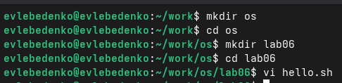

Подготовка к работе с vi

Нажимаю клавишу i и ввожу текст из задания.

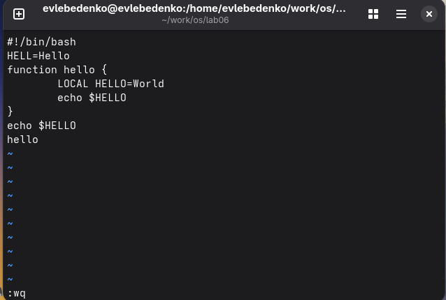

i

Нажимаю клавишу Esc для перехода в командный режим после завершения ввода текста. Нажимаю : для перехода в режим последней строки. Нажимаю w (записать) и q (выйти), а затем нажимаю клавишу Enter для сохранения моего текста и завершения работы. Делаю файл исполняемым.

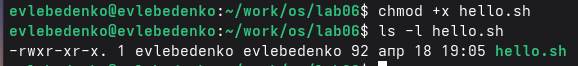

Устанавливаю курсор в конец слова HELL второй строки. Перехожу в режим вставки и замените на HELLO. Нажмаю Esc для возврата в командный режим.

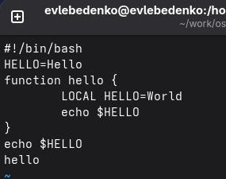

2G

Устанавливаю курсор на четвертую строку и стираю слово LOCAL.

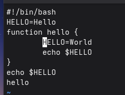

dw

Перехожу в режим вставки и наберите следующий текст: local, нажимаю Esc для возврата в командный режим.

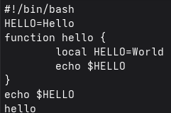

Меняю текст

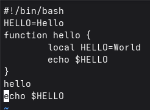

G, p

Нажмаю Esc для перехода в командный режим. Удаляю последнюю строку.

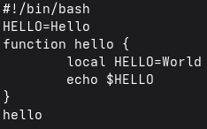

dd

Ввожу команду отмены изменений u для отмены последней команды.

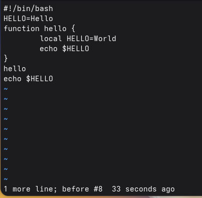

u

Ввожу символ : для перехода в режим последней строки. Записываю произведённые изменения и выхожу из vi.

# Выводы

Во время выполнения лабораторной работы я познакомилась с операционной системой Linux, получила практические навыки работы с редактором vi.